# The Lightning Jolt Script

In this lesson, we code the procedural lightning jolt.

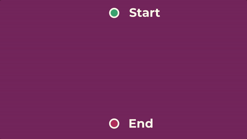

Let’s add some more variables to our `LightningJolt.gd` script:

```
extends Line2D

export (float, 0.5, 3.0) var spread_angle := PI/4.0
export (int, 1, 36) var segments := 12
```

As this is an effect we want to be independent of its parent, we set it as top-level to not inherit its parent’s rotation or position.

```
func _ready() -> void:
    set_as_toplevel(true)
```

## Generating the jolt procedurally

Let’s flesh out the `create()` method now. The `LightningBeam` will call this method and pass it the weapon’s position and the jolt’s target position.

In our `create()` function, we need to:

- Calculate each point of the lightning jolt by rotating roughly towards the end point, then moving forward until we’re close to the end point.
- Snap the sparks’ position to the end point.

First, we define some temporary variables:

- `_points` is the array of points we’ll add to as we move through the algorithm.
- `_current` is when our vector will extend from each loop. This will change as we move through the algorithm.
- `_segment_length` is the length of each segment. This is calculated based on the distance from the start and end point.

```
func create(start: Vector2, end: Vector2) -> void:

    var _points := []
    var _current := start
    var _segment_length := start.distance_to(end) / segments
```

We kick things off by adding the start point to the `_points` array.

For each segment, we get a random rotation based on our `spread_angle`.

We then create a new vector starting from our `_current` vector. `direction_to()` returns a unit vector towards our end point, so we multiply it by the `_segment_length`. We also use the vector method `rotated()` to rotate this new vector by the `_rotation` chosen above.

We add this vector to `_points`, update our `_current` vector, and repeat for as many segments we need.

Finally, we set the `Line2D` points to `_points` and set our sparks’ global position to the end point.

```
    _points.append(start)

    for segment in range(segments):
        var _rotation := rand_range(-spread_angle / 2, spread_angle / 2)
        var _new := _current + (_current.direction_to(end) * _segment_length).rotated(_rotation)
        _points.append(_new)
        _current = _new

    _points.append(end)
    points = _points

    sparks.global_position = end
```

We can test our function by calling the `create()` function in `_ready()`. Doing so runs our algorithm when the scene enters the scene tree to see how it works.

```
func _ready() -> void:
    set_as_toplevel(true)
    create(Vector2.ZERO, Vector2(400, 400))
```

[figure not shown]

That’s great, but we need to make it look more appealing. In the next part, we’ll improve the lighting jolt’s visuals and use the AnimationPlayer to tie everything together.

## Final LightningJolt.gd script

```
extends Line2D

export (float, 0.5, 3.0) var spread_angle := PI/4.0
export (int, 1, 36) var segments := 12

onready var sparks := $Sparks


func _ready() -> void:
    set_as_toplevel(true)


func create(start: Vector2, end: Vector2) -> void:

    var _points := []
    var _current := start
    var _segment_length := start.distance_to(end) / segments

    _points.append(start)

    for segment in range(segments):
        var _rotation := rand_range(-spread_angle / 2, spread_angle / 2)
        var _new := _current + (_current.direction_to(end) * _segment_length).rotated(_rotation)
        _points.append(_new)
        _current = _new

    _points.append(end)
    points = _points

    sparks.global_position = end
```